# Assignment 1 RepResearch

Filip Novotný

2017-10-27

## Loading and Preprocessing the Data

This assignment makes use of data from a personal activity monitoring device. This device collects data at 5 minute intervals through out the day. The data consists of two months of data from an anonymous individual collected during the months of October and November, 2012 and include the number of steps taken in 5 minute intervals each day.

The data is a comma delimited file, it includes 17,568 observations of 3 variables:

steps: Number of steps taken in a 5 min interval date: The date when the measurement was taken in YYY-MM-DD format interval: Identifier for the 5-min interval in which the measurement was taken

Firstly, you should set the right working directory: setwd() function

1. Load the data (the date column to character)

```r
# Clear the workspace
rm(list=ls())

# Load the data
activityData <- read.csv ("activity.csv", header = T, sep = ",", stringsAsFactors = F)
```

2. Convert the date column to the appropriate format

```r
activityData$date <- as.Date(activityData$date, "%Y-%m-%d")
str(activityData)
```

```
## 'data.frame':    17568 obs. of  3 variables:
##  $ steps   : int  NA NA NA NA NA NA NA NA NA NA ...
##  $ date    : Date, format: "2012-10-01" "2012-10-01" ...
##  $ interval: int  0 5 10 15 20 25 30 35 40 45 ...
```

```r
# Check the dimensions and a few rows of the newly created data frame
dim(activityData)
```

```
## [1] 17568     3
```

```r
head(activityData)
```

```
##   steps       date interval
## 1    NA 2012-10-01        0
## 2    NA 2012-10-01        5
## 3    NA 2012-10-01       10
## 4    NA 2012-10-01       15
## 5    NA 2012-10-01       20
## 6    NA 2012-10-01       25
```

During the first day of data collection we have several intervals with missing values that we will need to deal later with.

## The mean of the total number of steps taken per day

The following lines calculate the total number of steps per day and the mean number of daily steps.

```r
library (dplyr)
AvgDay <- activityData %>% group_by(date) %>%
          summarize(total.steps = sum(steps, na.rm = T),
                  mean.steps = mean(steps, na.rm = T))
```

The histogram of the total steps

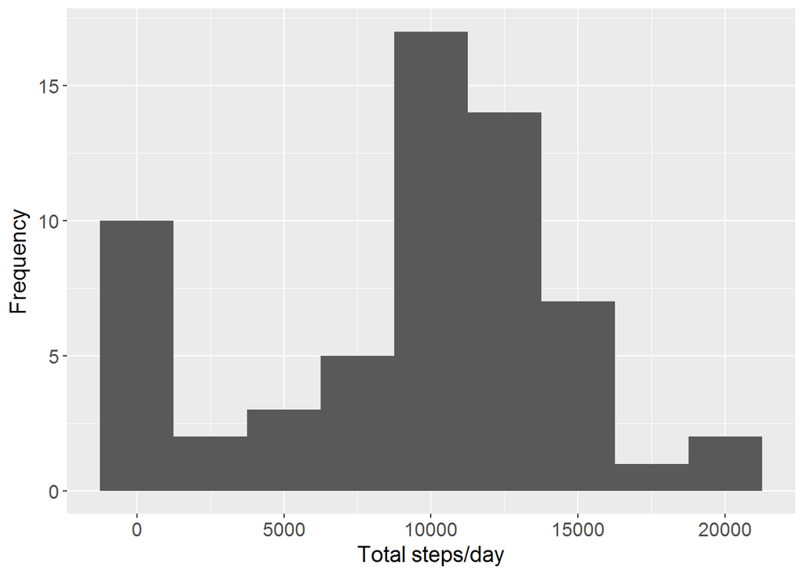

```r
library(ggplot2)
g <- ggplot(AvgDay, aes(x=total.steps))
g + geom_histogram(binwidth = 2500) + theme(axis.text = element_text(size = 12),
      axis.title = element_text(size = 14)) + labs(y = "Frequency") + labs(x = "Total steps/day")
```

The data is symmetrically distributed around the center of the distribution, except for one class at the extreme left.

Calculate the mean and median of the total number of steps taken per day

```r
summary(AvgDay$total.steps)
```

```
##    Min. 1st Qu.  Median    Mean 3rd Qu.    Max.
##       0    6778   10395    9354   12811   21194
```

```r
summary(AvgDay$mean.steps)
```

```
##    Min. 1st Qu.  Median    Mean 3rd Qu.    Max.    NA's
##  0.1424 30.6979 37.3785 37.3826 46.1597 73.5903       8
```

The mean and the median of the total steps are close in value. There are also 8 missing values.

## The Average Daily Activity Pattern

Make a time series plot of the 5-minute interval (x-axis) and the average number of steps taken, average across all days (y-axis)

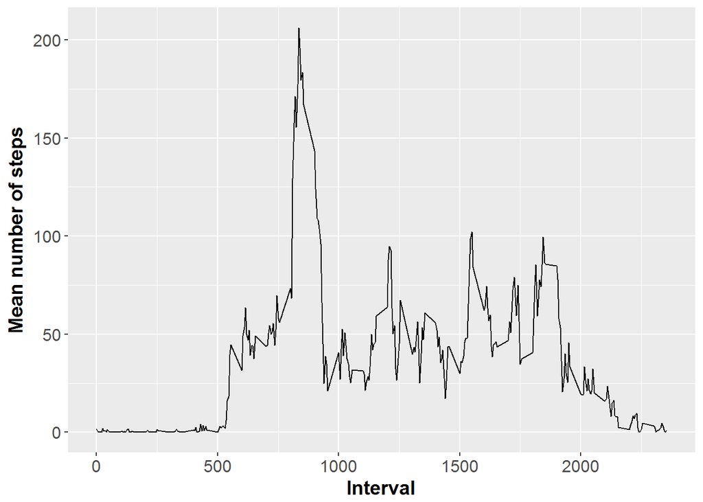

```r
AvgInterval <- activityData %>% group_by(interval) %>%
      summarize(mean.steps = mean(steps, na.rm = T))
g <- ggplot(AvgInterval, aes(x = interval, y = mean.steps))
g + geom_line() + theme(axis.text = element_text(size = 12),
      axis.title = element_text(size = 14, face = "bold")) +
      labs(y = "Mean number of steps") + labs(x = "Interval")
```

The largest amount of steps occurs between time intervals 500 and 1000. The maximum average number of steps is 206 and occurs in time interval #835.